# Corbin Carroll vs Ketel Marte (Statcast / StatAPI)

**Author:** Bowen Li

## Objective

This analysis compares **Corbin Carroll** and **Ketel Marte** using pitch-level Statcast data.

**Key questions** - How do their **plate appearance outcomes** differ? - How do their **home-run contact profiles** (launch speed × launch angle) compare? - Do they generate home runs from **similar pitch velocities and locations**?

## Setup

```r
library(dplyr)
```

```r
library(ggplot2)
library(patchwork)
library(tidyr)
library(viridis)
```

## Data Loading & Initial Inspection

Each row represents one pitch thrown to the batter.

```r
Corbin <- read.csv("Corbin_Carroll_plays_2023_2025.csv")
Ketel  <- read.csv("Ketel_Marte_plays_2023_2025.csv")
head(Ketel, 5)
```

```
##   season gamePk inning halfInning atBatIndex                startTime
## 1   2023 718770      1        top          1 2023-03-31T02:12:11.804Z
## 2   2023 718770      3        top         17 2023-03-31T02:39:31.972Z
## 3   2023 718770      6        top         43 2023-03-31T03:36:58.610Z
## 4   2023 718770      9        top         68 2023-03-31T04:42:58.999Z
## 5   2023 718765      1        top          1 2023-04-01T02:12:26.287Z
##                    endTime homeScore awayScore batter_id batter_name pitcher_id
## 1 2023-03-31T02:12:44.608Z        NA        NA    606466 Ketel Marte     628711
## 2 2023-03-31T02:39:47.386Z        NA        NA    606466 Ketel Marte     628711
## 3 2023-03-31T03:40:33.313Z        NA        NA    606466 Ketel Marte     628711
## 4 2023-03-31T04:44:33.952Z        NA        NA    606466 Ketel Marte     622075
## 5 2023-04-01T02:13:26.187Z        NA        NA    606466 Ketel Marte     669160
##    pitcher_name bat_side pitch_hand        event    eventType
## 1   Julio Urías        R          L Hit By Pitch hit_by_pitch
## 2   Julio Urías        R          L  Field Error  field_error
```

[output cut: 27 more lines]

## Plate Appearance Outcome Comparison

The tables below summarize counts and percentages of events for each player between 2023 to 2025 season.

### Corbin Carroll

```r
Corbin %>%
  count(event, sort = TRUE) %>%
  mutate(pct = round(n / sum(n) * 100, 2))
```

```
##                         event   n   pct
## 1                   Strikeout 407 20.37
## 2                   Groundout 342 17.12
## 3                      Single 246 12.31
## 4                      Flyout 228 11.41
## 5                        Walk 193  9.66
## 6                     Pop Out 128  6.41
## 7                     Lineout  97  4.85
## 8                      Double  84  4.20
## 9                    Home Run  78  3.90
## 10                   Forceout  45  2.25
## 11                     Triple  42  2.10
## 12               Hit By Pitch  30  1.50
## 13                    Sac Fly  17  0.85
## 14           Grounded Into DP  16  0.80
## 15                   Sac Bunt   9  0.45
## 16                Field Error   7  0.35
## 17         Caught Stealing 2B   6  0.30
## 18            Fielders Choice   6  0.30
## 19                Double Play   5  0.25
## 20                Intent Walk   5  0.25
## 21             Bunt Groundout   2  0.10
## 22               Bunt Pop Out   1  0.05
## 23         Caught Stealing 3B   1  0.05
## 24        Fielders Choice Out   1  0.05
## 25 Pickoff Caught Stealing 2B   1  0.05
## 26      Strikeout Double Play   1  0.05
```

### Ketel Marte

```r
Ketel %>%
  count(event, sort = TRUE) %>%
  mutate(pct = round(n / sum(n) * 100, 2))
```

```
##                    event   n   pct
## 1              Groundout 357 19.75
## 2              Strikeout 300 16.59
## 3                 Single 263 14.55
## 4                 Flyout 219 12.11
## 5                   Walk 188 10.40
## 6               Home Run  91  5.03
## 7                Pop Out  84  4.65
## 8                Lineout  78  4.31
## 9                 Double  77  4.26
## 10      Grounded Into DP  39  2.16
## 11              Forceout  27  1.49
## 12          Hit By Pitch  19  1.05
## 13               Sac Fly  18  1.00
## 14           Intent Walk  15  0.83
## 15                Triple  11  0.61
## 16           Field Error   8  0.44
## 17   Fielders Choice Out   5  0.28
## 18       Fielders Choice   4  0.22
## 19           Double Play   2  0.11
## 20 Strikeout Double Play   2  0.11
## 21  Caught Stealing Home   1  0.06
```

## Launch Speed × Launch Angle Profile — Home Runs

```r
Corbin_HR <- Corbin %>% filter(event == "Home Run")
Ketel_HR  <- Ketel  %>% filter(event == "Home Run")
```

### Scatterplots (Raw Outcomes)

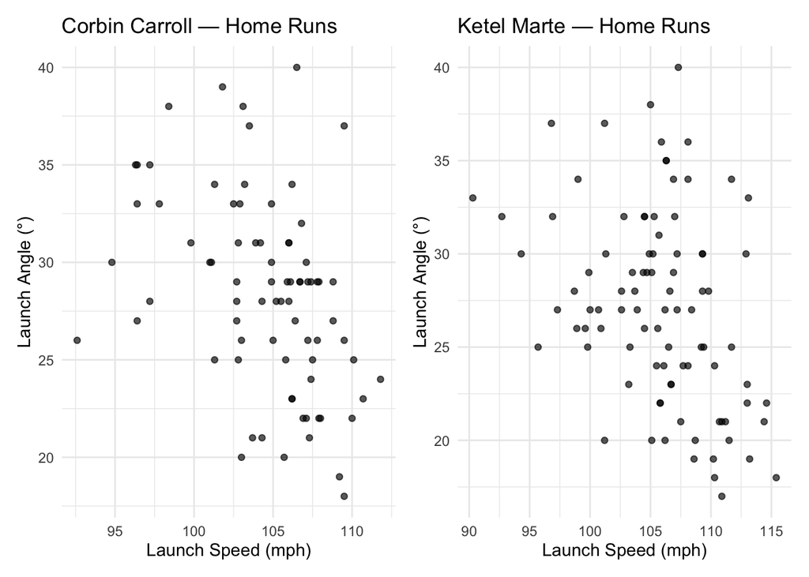

```r
p1 <- ggplot(Corbin_HR, aes(launch_speed, launch_angle)) +
  geom_point(alpha = 0.65) +
  labs(
    title = "Corbin Carroll — Home Runs",
    x = "Launch Speed (mph)",
    y = "Launch Angle (°)"
  ) +
  theme_minimal()

p2 <- ggplot(Ketel_HR, aes(launch_speed, launch_angle)) +
  geom_point(alpha = 0.65) +
  labs(
    title = "Ketel Marte — Home Runs",
    x = "Launch Speed (mph)",
    y = "Launch Angle (°)"
  ) +
  theme_minimal()

p1 + p2
```